# Numerical Methods of Accelerator Physics

## Lecture Series by Dr. Adrian Oeftiger

### Guest Lecture by Dr. Michael Schenk

[figure not shown]

### Part 11: 20.01.2023

## Run this notebook online!

Interact and run this jupyter notebook online:

1. via the public mybinder.org service:

2. on the [local TU Darmstadt jupyterhub $\nearrow$](https://tu-jupyter-i.ca.hrz.tu-darmstadt.de/) (using your TU ID)

$\implies$ make sure you installed all the required python packages (see the README)!

Finally, also find this lecture rendered [as HTML slides on github $\nearrow$](https://aoeftiger.github.io/TUDa-NMAP-11/) along with the [source repository $\nearrow$](https://github.com/aoeftiger/TUDa-NMAP-11).

## Run this first!

Imports and modules:

```python
from config import (np, plt)
from scipy.constants import m_p, e, c
%matplotlib inline
```

## Refresher!

- closed orbit distortion due to dipole error
- periodic and non-periodic solutions for the propagation of the equilibrium offset
- local orbit correction: 3-corrector bump
- orbit response matrix $\Omega_{ij}=\cfrac{\Delta x_i}{\theta_j}$ for BPM measurement $\Delta x_i$ and corrector angle $\theta_j$
- global orbit correction: SVD algorithm

## Preparation!

- Overview by Dr. Andrea Santamaria Garcia: [Introduction to machine learning](https://moodle.tu-darmstadt.de/mod/lti/view.php?id=1101645)

## Today!

1. Introduction to reinforcement learning
2. Reinforcement learning formalism
3. Q-learning
4. Actor-critic methods

#### Disclaimer

- Today's introduction to reinforcement learning (RL) is by no means mathematically complete
- The idea is to give a high-level overview and some first ideas on the subject to hopefully spark your interest :)
- RL is a fascinating field: if you want to learn more, there are some great resources at the end

## Part I: introduction to reinforcement learning

## Machine learning landscape

[figure not shown]

image by [GeekStyle](https://www.linkedin.com/pulse/business-intelligence-its-relationship-big-data-geekstyle)

- **Supervised learning**
  - **Goal:** optimize for best mapping $F(x) = y$ using a *labelled* dataset $(x, y)$
  - **Data:** $y$ is sometimes referred to as the ground truth or the label
- **Unsupervised learning**
  - **Goal:** identify structure in data. *E.g. clustering: optimize for similarity of datapoints within cluster*
  - **Data:** no labelled dataset is available / needed
- **Reinforcement learning**
  - **Goal:** determine how to make optimal decisions in an environment *(optimize for best behavior function)*
  - **Data:** an agent is actively interacting with the environment through trial-and-error and collects data (including positive or negative rewards)
  - Closest to artificial intelligence: provide **minimal external input / supervision** and let the agent explore and learn by itself

## Reinforcement learning examples

**DeepMind, 2015 & 2017: AlphaGo & AlphaZero**

- One of the more famous RL successes: agent learning to play the game of Go and beating world champion Lee Sedol
- In case you want to know more: [documentary on YouTube](https://www.youtube.com/watch?v=WXuK6gekU1Y)

[figure not shown]

[DeepMind AlphaGo](https://www.deepmind.com/research/highlighted-research/alphago)

## Reinforcement learning examples

**OpenAI, 2019: hide-and-seek**

- RL agents learning to play hide-and-seek in a multi-agent setting
- Recommend to watch the [short video](https://openai.com/blog/emergent-tool-use/)

[figure not shown]

[OpenAI](https://openai.com/blog/emergent-tool-use/)

## Reinforcement learning examples

**OpenAI, 2022: [ChatGPT](https://openai.com/blog/chatgpt/)**

- Combination of RL and supervised learning
- Impressive chatbot using a language model with 175 billion parameters
- Try for yourself and ask it anything! It can also write or comment code, create poems ...

[figure not shown]

[output by ChatGPT](https://openai.com/blog/chatgpt/)

## Reinforcement learning examples

**DeepMind & EPFL, 2022: tokamak control**

- Shaping and maintaining high-temperature plasma within tokamak vessel is challenging
- Requires high-dimensional, high-frequency, closed-loop control using magnetic actuator coils
- Paper describes RL agent that was successfully trained as a magnetic controller

[figure not shown]

[Paper](https://www.nature.com/articles/s41586-021-04301-9), [EuroFusion](https://www.spektrum.de/news/auf-verschlungenen-pfaden/1698480)

## Reinforcement learning examples

**DeepMind, 2022: AlphaTensor**

- Matrix multiplication is a very fundamental mathematical operation
- Improving its computational efficiency can benefit many fields
- RL agent discovered more computationally efficient algorithms than developed by humans

[figure not shown]

[Paper](https://www.nature.com/articles/s41586-022-05172-4)

## What is reinforcement learning?

- **Application:** online optimal control, decision-making tasks
- **Goal:** learn optimal behavior in given environment
- **Trial-and-error learning:** agent takes actions in environment and collects rewards
- We provide **minimal input**: reward function, state definition

[figure not shown]

### An example: Pacman

- For games it is typically easy to define what the state, actions, and rewards are
  - **State:** where am I? Where are ghosts, snacks, cookies, walls? *(discrete set)*
  - **Action:** up, down, left, right *(discrete set)*
  - **Reward:** food (+), ghosts (-)

[figure not shown]

### Another example: beam trajectory steering

- Maximize integrated beam on target
  - **State:** beam position somewhere in the line *(continuous variable)*
  - **Action:** increase or decrease dipole kick angle, or strength *(continuous variable)*
  - **Reward:** amount of beam on target

[figure not shown]

## Today's lecture

- There are **various RL algorithms** suitable for different types of tasks
- Often the choice of algorithm depends on whether we deal with **discrete or continuous state-action spaces**
- We will go through:
  1. **Discrete states, discrete actions:** Q-learning with a lookup table
  2. **Continuous states, discrete actions:** Q-learning with a neural network (deep Q-learning or DQN)
  3. **Continuous states, continuous actions:** actor-critic algorithm $\Rightarrow$ what we typically need to control accelerator systems ...

## Our environment

- A small grid maze
- There are fires and a target field
- A player, or agent has to navigate through and find the target field

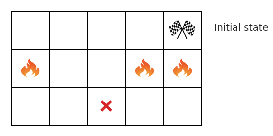

```python
from qlearning.core import Maze

env = Maze(height=3, width=5)
env.plot(title='Initial state');
```

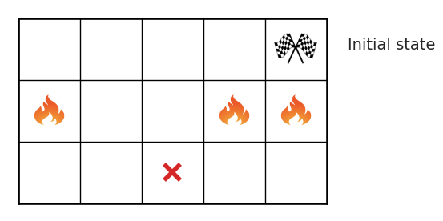

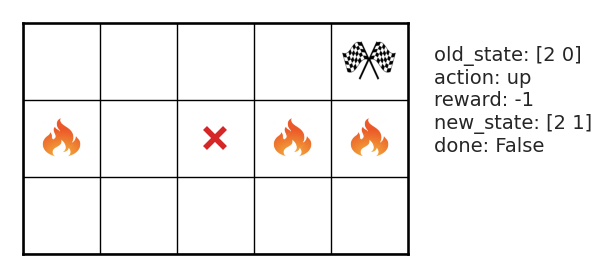

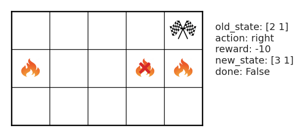

```python
# Take some actions
env.plot(title='Initial state')
env.step(action='up')
env.plot()
env.step(action='right')
env.plot();
```

### RL definitions

- **State:** player / agent position ( **x** ) whose coordinates are defined by a tuple $(x, y)$
- **Action:** 'up', 'down', 'left', 'right'
- **Reward:** every action comes with a reward, depending on the new state we end up in
  - Taking a step into an empty field: -1
  - Bumping into walls: -5
  - Going through fire: -10
  - Reaching the goal: +30

## RL is about taking the best decisions ...

- Obviously there are **better and worse trajectories to reach the target**. "Better" and "worse" refer to **how much reward** we can collect along the way.
- We will get back to that

**Exercise 1**

Using the reward definitions from the previous slide, try to calculate the cumulative rewards for the trajectories shown below. Can you tell which of the paths are equally good / bad?

[figure not shown]

## Part II: reinforcement learning formalism

### Markov process

- A **memoryless random process** consisting of a **set of states $S$ and state transition probabilities**
- The *state* should possess the **Markov property**:
  - At every time $t$, the future evolution of the environment depends only on the information contained in the current state $s_t$, but not on the history of past states $s_{t-1}, s_{t-2}, ...$ *(memorylessness)*
  - In other words: $P(s_{t+1} | s_t) = P(s_{t+1} | s_{t}, s_{t-1}, ..., s_0)$
- **Examples:**
  - Chess: the positions of the figures on the board fully define the state. There are many ways to reach the specific state, but it does not matter for making the next move nor for the future evolution of the game.
  - Flight of a cannonball: state given by its current position and velocity provides enough information to predict the future.

[figure not shown]

image by [D. Silver - Lecture on RL](https://www.davidsilver.uk/wp-content/uploads/2020/03/MDP.pdf)

$S = \{\text{Class 1, Class 2, Class 3, Facebook, Pub, Pass, Sleep}\}$  
*Note that "Sleep" is also called a* *terminal state**, because once in it we will never leave it.*

### Markov reward process

- A Markov process that has in addition a **reward function** and a **discount factor** $\gamma \in [0, 1]$
- **Return** $G_t$: sum of discounted future rewards

$$G_t = \sum_k \gamma^k \, r_{t+k}$$

- $\gamma$ controls the relative importance of immediate vs future rewards
  - $\gamma \rightarrow 0$: we only care about immediate rewards
  - $\gamma \rightarrow 1$: we care about rewards far in the future

[figure not shown]

image by [D. Silver - Lecture on RL](https://www.davidsilver.uk/wp-content/uploads/2020/03/MDP.pdf)

- **Example:** C1 $\rightarrow$ C2 $\rightarrow$ C3 $\rightarrow$ Pass $\rightarrow$ Sleep

$\Rightarrow$ Return: $G_0 = (-2) + 0.5 * (-2) + 0.5^2 (-2) + (+10) * 0.5^3 = -2.25$ *(with $\gamma = 0.5$)*

### Markov decision process (MDP)

- Extend Markov reward process by adding **decision making**: set of possible actions $A$ (= action space)

[figure not shown]

image by [D. Silver - Lecture on RL](https://www.davidsilver.uk/wp-content/uploads/2020/03/MDP.pdf)

*N.B.: stochastic state transitions are still allowed (if we decide to go to the Pub, anything can happen).*  
*Today we will work with fully deterministic MDPs only.*

- **Episodic MDP**
  - Each episode ends in a terminal state
  - Return $G_t$ is the sum of discounted rewards collected from time $t$ till end of episode
  - Episodes are independent
- **Continuous MDP**
  - Continues indefinitely: has no terminal states
  - Very important that discount factor $\gamma < 1$ to avoid infinite returns
  - Also known as infinite horizon MDP

### Policy $\pi$

- The policy defines the decision making or **behavior of the agent**
- It is a **probability distribution over the state-action space**. You can also think of it as a mapping that assigns to each state-action pair $(s, a)$ a probability

$$\pi: S \times A \rightarrow [0, 1]$$

- $S$ and $A$ are the state and action spaces, respectively
  - For our maze: $S = \{[0, 0], [0, 1], ..., [\text{width}-1, \text{height}-1]\}$ and $A = \{\text{'up', 'down', 'left', 'right'}\}$.

**Exercise 2**

Let's get back to the maze! For now we do not care about optimal decisions. Instead, try to **implement a random policy**, i.e. every action $a \in \{\text{'up', 'down', 'left', 'right'}\}$ is picked with equal probability no matter what state the agent is in.

**a)** Initialize a Maze with `height=3, width=2` and complete the `all_actions` list.

**b)** Look at every step of the output: is the movement of the agent ( **x** ) and the rewards obtained consistent with your expectations?

**c)** Change the random number seed, rerun and observe.

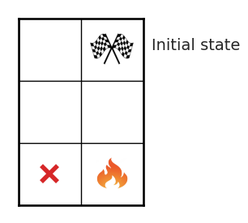

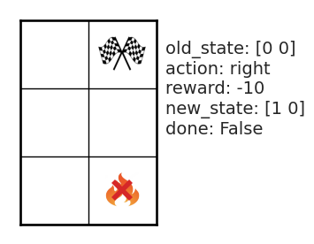

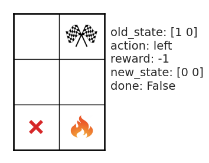

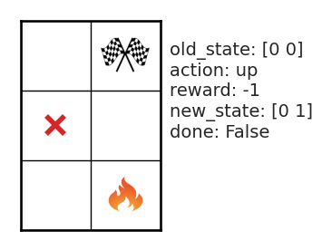

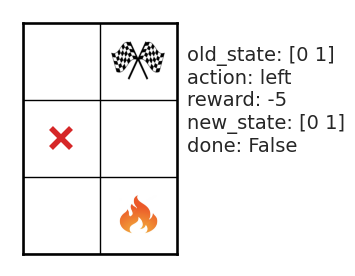

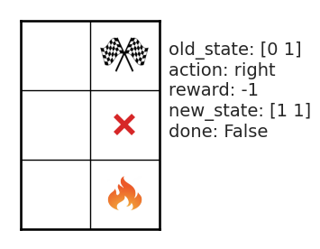

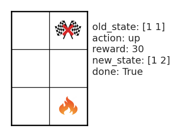

```python
from qlearning.core import Maze

np.random.seed(123457)

env = Maze(height=3, width=2) # FILL HERE)
env.plot(title='Initial state')

all_actions = ['up', 'left', 'down', 'right'] # ... FILL HERE]

done = False
while not done:
    action = np.random.choice(all_actions)
    state, action, reward, new_state, done = env.step(action)
    env.plot();
```

## RL objective

- **Find optimal behavior in a given environment:** in every state we want the agent to take the best action
- This is also known as the **optimal policy** $\pi^*$
- Formally, $\pi^*$ **maximizes the return** $G_t = \sum_k \gamma^k \, r_{t+k}$, i.e. the cumulative sum of discounted future rewards.
- **For our maze, RL will solve ...**
  - For any given field that we are currently on (= state), what is the action that maximizes the sum of rewards collected over time?
  - Or: from where I stand - how can I reach the target field with the **least steps and not going through fires** (if possible) ?

## RL taxonomy

- There are many **different algorithms** for finding the optimal policy $\pi^*$
- They all have their pros and cons
  - Often the **sample-efficiency** is crucial
  - It tells us **how many interactions with the environment** (= how many data samples) we need to solve the RL problem
  - E.g. for **accelerator systems**: we want to train the agent with **as little beam time as possible** as it is very expensive
- **Today:** we are going to look at **Q-learning**. It is one of the **core ideas** of many RL algorithms, such as
  - Deep Q-learning (DQN)
  - Actor-critic methods (DDPG, TD3, SAC)

[figure not shown]

image by [Open AI - Spinning Up](https://spinningup.openai.com/en/latest/spinningup/rl_intro2.html)

[figure not shown]

image adapted from [S. Levine, "Deep Reinforcement Learning" (lecture)](https://rail.eecs.berkeley.edu/deeprlcourse/)

## Intermediate summary

- The goal of RL is to **make optimal decisions** (*take actions*) in an environment based on some observables (*state*)
- **Example environments:** game, control system (e.g. fusion reactor, tuning accelerator parameters), trading, ...
- The **quality of a decision** made is quantified by a **reward**
- Through **trial-and-error** the RL agent collects rewards and can eventually learn the **best behavior** (*optimal policy* $\pi^*$)
- Formally this is described as a **Markov decision process (MDP)**

## Part III: Q-learning

## Q-learning

- Employs a **state-action value function**

$$Q: S \times A \rightarrow \mathbb{R}$$

to solve the RL problem

- The Q-value $Q(s, a)$ characterizes the **"quality" of the state-action pair** $(s, a)$
  - Quality is measured as the **expected return** acting according to a certain policy

  $$Q(s, a) = \mathbb{E}[G_t | S_t = s, A_t = a]$$
  - Reminder: $G_t = \sum_k \gamma^k \, r_{t+k}$
- **Temporal difference (TD) learning**
  - We can write the Q-value of $(s, a)$ as a sum of immediate reward $r$ plus discounted Q-value of the next state-action pair $(s', a')$
  - *N.B.: we are acting greedily, hence the $\text{max}$ operation*

[figure not shown]

- **Temporal difference (TD) rule**
  - Q-values are initially unknown / random, but can be learned **iteratively** following the TD update rule

$$Q(s, a) \leftarrow Q(s, a) + \alpha \underbrace{[\underbrace{r + \gamma \text{max}_{a'} \, Q(s', a')}_{\text{target}} - \underbrace{Q(s, a)}_{\text{current prediction}}]}_{\text{TD error}},$$

where $\alpha$ is the learning rate

- Uses **trial-and-error experiences** collected by the agent in one step $(s, a, r, s')$: *state, action, reward, next state*.
- This is the **core idea of Q-learning** and is a result of one of the Bellman equations

## Obtaining the optimal policy

- Once Q-values have converged, it is easy to read off the optimal policy $\pi^*$

$$ \pi^*(s, a) = \left\{ \begin{array}{ll} 1 & \mbox{if } a = \text{argmax}_{a'} \, Q(s, a') \\ 0 & \mbox{otherwise.} \end{array} \right. $$

- This is also known as the **greedy policy**: it acts greedily in terms of expected return by assigning probability $1$ to the action that maximizes the Q-function.

## How to implement Q-learning?

- We need a way to **track and update the Q-value** for each state-action pair
  - Traditional Q-learning: **Q-table**
  - Deep Q-learning: **neural network**

[figure not shown]

image by [AssemblyAI](https://www.assemblyai.com/blog/reinforcement-learning-with-deep-q-learning-explained/)

## Some challenges

- Reward engineering
- Definition of the state, which is sometimes only partially observable
- Hyperparameter tuning, making training stable
- Exploration vs exploitation ...

### Exploration-exploitation trade-off

- To learn the best policy in the most efficient manner, we need a **trade-off between exploration and exploitation**.
- We have to **ensure that the agent keeps exploring** new actions during training and does not just always follow the path that provides the highest expected return
- After all, Q-values might **not have converged yet**, there may still be better solutions than currently known

[figure not shown]

image by [Berkeley AI course](https://inst.eecs.berkeley.edu/~cs188/sp20/assets/lecture/lec15_6up.pdf)